# Simple Linear Regression

INSOFE Lab

02nd Sep 2018

**NOTE** Before starting, please remember to clear your environment, you can do that by running the following code chunk

```r
rm(list = ls(all=TRUE))
```

# Agenda

- Reading & Understanding the Data
- Data Description
- Basic Stats
- Covariance and Correlation
- Linear Regression
- Plotting the data
- Summary Statistics
- Basic assessment of the model

# Reading & Understanding the Data

Read the cars dataset which comes in built in R.

```r
data(cars);
attach(cars);
```

# Data Description

Basic description about the dataset

```r
dim(cars); #Size of data
```

```
## [1] 50  2
```

```r
names(cars); #names of attributes in the cars dataframe
```

```
## [1] "speed" "dist"
```

```r
summary(cars);
```

```
##      speed           dist
##  Min.   : 4.0   Min.   :  2.00
##  1st Qu.:12.0   1st Qu.: 26.00
##  Median :15.0   Median : 36.00
##  Mean   :15.4   Mean   : 42.98
##  3rd Qu.:19.0   3rd Qu.: 56.00
##  Max.   :25.0   Max.   :120.00
```

```r
head(cars);
```

```
##   speed dist
## 1     4    2
## 2     4   10
## 3     7    4
## 4     7   22
## 5     8   16
## 6     9   10
```

We take the speed to be the independent variable (based on domain knowledge) and stopping distance as the dependent variable

# Basic Stats

Compute basic statistics

```r
print("Mean and standard deviation of speed : ");
```

```
## [1] "Mean and standard deviation of speed : "
```

```r
print(toString(mean(speed)));
```

```
## [1] "15.4"
```

```r
print(toString(sd(speed)));
```

```
## [1] "5.28764443523478"
```

```r
print("Mean and standard deviation of dist : ");
```

```
## [1] "Mean and standard deviation of dist : "
```

```r
print(toString(mean(dist)));
```

```
## [1] "42.98"
```

```r
print(toString(sd(dist)));
```

```
## [1] "25.7693774920259"
```

# Covariance and Correlation

*Compute the covariance and correlation between dependent and independent variables* Verify that these values match the covariance and correlation computed using Excel. *You are encouraged to ask other questions (not just about prices of cars) and answer them using the dataset below.

```r
covariance_speed_dist = cov(speed,dist);
correlation_speed_dist = cor(speed,dist);

# verifying the formula
r= covariance_speed_dist/(sd(speed)*sd(dist))
r
```

```
## [1] 0.8068949
```

```r
print("Covariance between speed and dist = ");
```

```
## [1] "Covariance between speed and dist = "
```

```r
print(toString(covariance_speed_dist));
```

```
## [1] "109.94693877551"
```

```r
print("Correlation between speed and dist = ");
```

```
## [1] "Correlation between speed and dist = "
```

```r
print(toString(correlation_speed_dist));
```

```
## [1] "0.80689490068921"
```

# Linear Regression

‘lm’ function is used for Linear Regression

```r
linefit = lm(dist~speed,data=cars);
linefit
```

```
##
## Call:
## lm(formula = dist ~ speed, data = cars)
##
## Coefficients:
## (Intercept)        speed
##     -17.579        3.932
```

```r
linefit_trial = lm(dist~.,data=cars);
linefit_trial
```

```
##
## Call:
## lm(formula = dist ~ ., data = cars)
##
## Coefficients:
## (Intercept)        speed
##     -17.579        3.932
```

# Plotting the data

- Plot Distance vs Speed.
- Superimpose the Predicted line over original data.

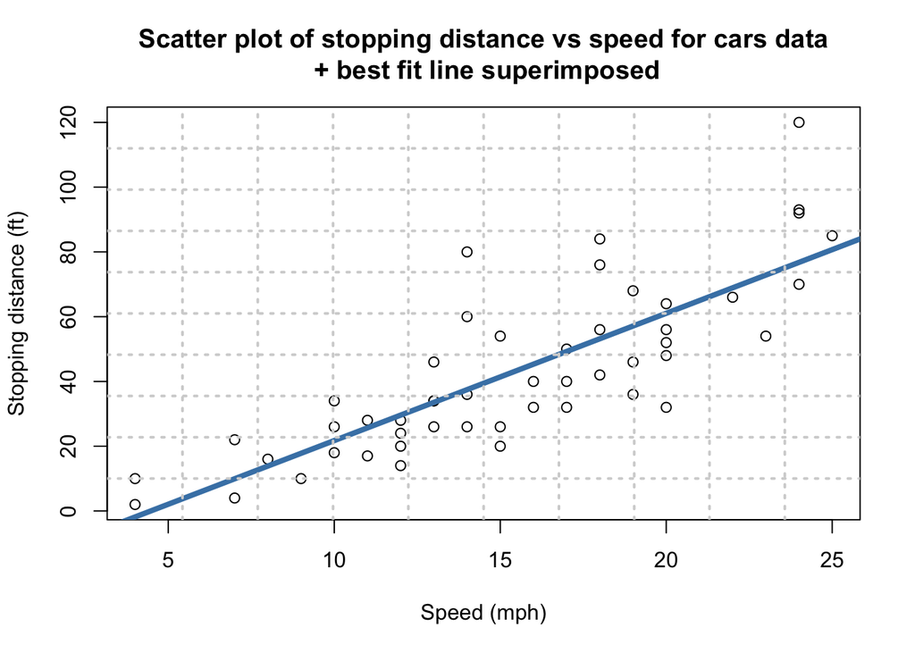

```r
plot(speed,dist,xlab="Speed (mph)",ylab="Stopping distance (ft)",main="Scatter plot of stopping distance vs speed for cars data\n + best fit line superimposed");
abline(linefit,col="steelblue",lty=1,lwd=4);
grid(10,10,lwd=2);
```

# Summary Statistics

Read off key outputs of the fitted model using the summary function

```r
summary(linefit);
```

```
##
## Call:
## lm(formula = dist ~ speed, data = cars)
##
## Residuals:
##     Min      1Q  Median      3Q     Max
## -29.069  -9.525  -2.272   9.215  43.201
##
## Coefficients:
##             Estimate Std. Error t value Pr(>|t|)
## (Intercept) -17.5791     6.7584  -2.601   0.0123 *
## speed         3.9324     0.4155   9.464 1.49e-12 ***
## ---
## Signif. codes:  0 '***' 0.001 '**' 0.01 '*' 0.05 '.' 0.1 ' ' 1
##
## Residual standard error: 15.38 on 48 degrees of freedom
## Multiple R-squared:  0.6511, Adjusted R-squared:  0.6438
## F-statistic: 89.57 on 1 and 48 DF,  p-value: 1.49e-12
```

# Basic assessment of the model

Is the model significant? Are the individual coefficients significant? What is the RSquared value?